# Statistics for Bioengineering - Week 5

# Identifying and Removing Outliers

## Fibroblast Cell Culture BMP/Sox9 Experiment

- A colleague has shared data from a cell culture experiment measuring BMP4 and SOX9 gene expression (relative expression units from qPCR).
- They want to model BMP4 expression as a function of SOX9 expression across 80 samples.
- However, they suspect there may be some **data entry errors** and **outliers** in the dataset.
- Your job is to fit a linear model, use diagnostic plots to identify the problematic observations, decide which to remove, and then refit the model.
- Download the file `cell_culture_expression.csv` and move through the slides

## Types of Outliers to Watch For

Before we dive in, recall the different ways an observation can be unusual:

- **Data entry errors**: Values that are off by an order of magnitude (e.g., someone typed 165 instead of 16.5). These are unambiguously wrong and should be corrected or removed.
- **High leverage points**: Observations with extreme predictor ($x$) values. They have outsized *potential* to influence the fit, but may not actually distort it if they fall near the regression line.
- **High residual points**: Observations far from the fitted line in the $y$ direction but with typical $x$ values. These inflate the residual variance but may not drastically shift the slope.
- **High influence points**: The most dangerous — observations with *both* high leverage and a large residual. These can pull the entire regression line toward them, distorting slope and intercept estimates. Cook’s distance captures this combined effect.

## Import and Plot the Raw Data

**Tip**

Always label your points with sample IDs when looking for outliers — you need to know *which* observations to investigate!

- Output
- Code
- Interpretation

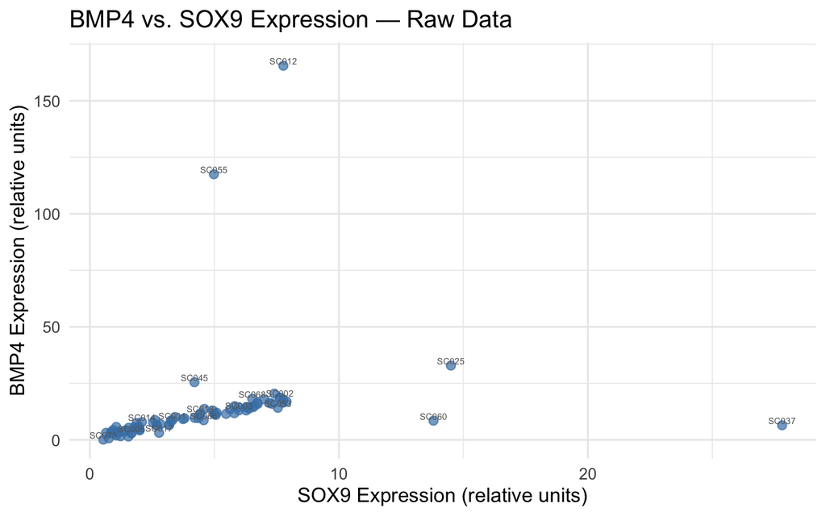

```r
expr <- read_csv("data/cell_culture_expression.csv")

ggplot(expr, aes(x = sox9_expression, y = bmp4_expression)) +
  geom_point(color = "steelblue", alpha = 0.7, size = 2.5) +
  geom_text(aes(label = sample_id), size = 2.2, nudge_y = 2, color = "gray40",
            check_overlap = TRUE) +
  labs(
    x = "SOX9 Expression (relative units)",
    y = "BMP4 Expression (relative units)",
    title = "BMP4 vs. SOX9 Expression — Raw Data"
  ) +
  theme_minimal(base_size = 14)
```

- The scatterplot with labeled sample IDs allows visual identification of potential outliers – points far from the main cluster.
- Labeling points is essential for outlier analysis because you need to trace suspicious observations back to the original data for investigation.
- The `check_overlap = TRUE` argument prevents label text from overlapping, improving readability.

## Fit the Initial Model

- Notice that the $R^2$ is lower than we might expect for a direct regulatory relationship.
- Some of the unexplained variance is likely due to the outliers pulling the fit.
- Output
- Code
- Interpretation

| term | estimate | std.error | statistic | p.value |
| --- | --- | --- | --- | --- |
| (Intercept) | 7.1536 | 3.7520 | 1.9066 | 0.0603 |
| sox9_expression | 1.3384 | 0.6292 | 2.1272 | 0.0366 |

| r.squared | adj.r.squared | sigma | statistic | p.value | df | logLik | AIC | BIC | deviance | df.residual | nobs |
| --- | --- | --- | --- | --- | --- | --- | --- | --- | --- | --- | --- |
| 0.0548 | 0.0427 | 21.3758 | 4.5249 | 0.0366 | 1 | -357.4831 | 720.9662 | 728.1123 | 35640.11 | 78 | 80 |

```r
lm_expr_raw <- lm(bmp4_expression ~ sox9_expression, data = expr)
tidy(lm_expr_raw) |> kable(digits = 4)
glance(lm_expr_raw) |> kable(digits = 4)
```

- The initial model fit shows the coefficient estimates and $R^2$ with outliers still present in the data.
- The $R^2$ is lower than expected for a direct regulatory relationship, likely because outliers are inflating the residual variance.
- These baseline statistics will be compared to the cleaned model to quantify the impact of outlier removal.

## Visualize the Fit with Outliers Present

- Output
- Code
- Interpretation

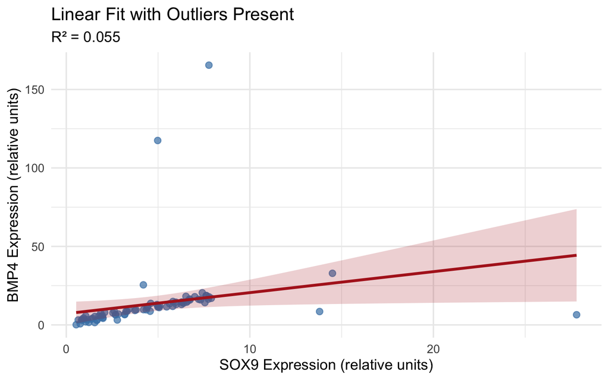

```r
ggplot(expr, aes(x = sox9_expression, y = bmp4_expression)) +
  geom_point(color = "steelblue", alpha = 0.7, size = 2.5) +
  geom_smooth(method = "lm", se = TRUE, color = "firebrick",
              fill = "firebrick", alpha = 0.2) +
  labs(
    x = "SOX9 Expression (relative units)",
    y = "BMP4 Expression (relative units)",
    title = "Linear Fit with Outliers Present",
    subtitle = paste0("R² = ", round(summary(lm_expr_raw)$r.squared, 3))
  ) +
  theme_minimal(base_size = 14)
```

- The regression line with outliers present is visibly pulled away from the main data cloud by the extreme observations.
- The wide confidence ribbon reflects the increased uncertainty caused by the outliers inflating residual variance.
- After removing outliers, the fit should tighten considerably, with a narrower confidence band and steeper/shallower slope.

## Diagnostic Plots to Identify Outliers

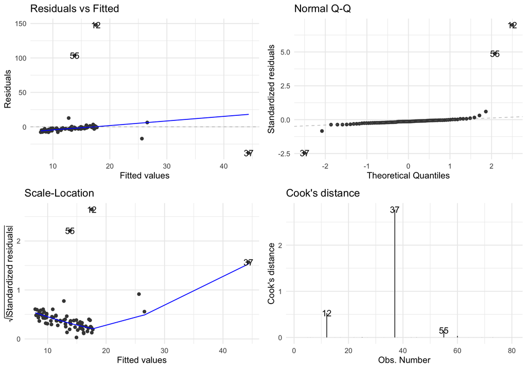

```r
autoplot(lm_expr_raw, which = 1:4, ncol = 2) +
  theme_minimal(base_size = 12)
```

## Cook’s Distance

- We can extract Cook’s distance values and identify the most influential observations programmatically.
- A common threshold for Cook’s distance is $4/n$. Values exceeding this warrant closer inspection.
- Values approaching or exceeding 1 are almost certainly problematic.
- Output
- Code
- Interpretation

| sample_id | bmp4_expression | sox9_expression | std_resid | leverage | cooks_d |
| --- | --- | --- | --- | --- | --- |
| SC037 | 6.45 | 27.80 | -2.4568 | 0.4789 | 2.7738 |
| SC012 | 165.50 | 7.77 | 6.9959 | 0.0212 | 0.5306 |
| SC055 | 117.50 | 4.98 | 4.8813 | 0.0126 | 0.1524 |

```r
expr_diag <- expr |>
  mutate(
    cooks_d = cooks.distance(lm_expr_raw),
    leverage = hatvalues(lm_expr_raw),
    std_resid = rstandard(lm_expr_raw)
  )

# Flag observations with Cook's D > 4/n (common threshold)
threshold <- 4 / nrow(expr)

expr_diag |>
  filter(cooks_d > threshold) |>
  select(sample_id, bmp4_expression, sox9_expression, std_resid, leverage, cooks_d) |>
  arrange(desc(cooks_d)) |>
  kable(digits = 4)
```

- Cook’s distance values above the $4/n$ threshold flag observations that have a disproportionate influence on the model fit.
- The table shows each flagged observation’s expression values, standardized residual, leverage, and Cook’s distance, helping distinguish data entry errors from biological outliers.
- Observations with both high leverage and large residuals (high Cook’s distance) are the most dangerous – they can substantially distort slope and intercept estimates.

## Visualizing Cook’s Distance

- Output
- Code
- Interpretation
- Enhancement

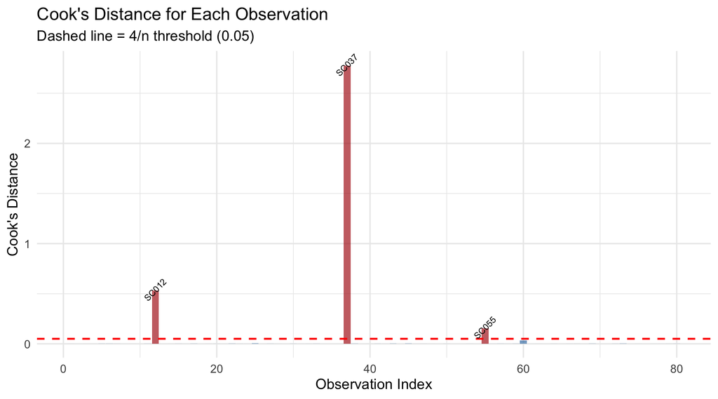

```r
expr_diag <- expr_diag |>
  mutate(row_num = row_number())

threshold <- 4 / nrow(expr)

ggplot(expr_diag, aes(x = row_num, y = cooks_d)) +
  geom_col(fill = ifelse(expr_diag$cooks_d > threshold, "firebrick", "steelblue"),
           alpha = 0.7) +
  geom_hline(yintercept = threshold, linetype = "dashed", color = "red", linewidth = 0.8) +
  geom_text(data = expr_diag |> filter(cooks_d > threshold),
            aes(label = sample_id), size = 2.8, nudge_y = 0.01, angle = 45) +
  labs(
    x = "Observation Index",
    y = "Cook's Distance",
    title = "Cook's Distance for Each Observation",
    subtitle = paste0("Dashed line = 4/n threshold (", round(threshold, 4), ")")
  ) +
  theme_minimal(base_size = 13)
```

- The bar plot of Cook’s distance makes it easy to spot which observations exceed the threshold (red bars above the dashed line).
- Observations with the highest Cook’s distance values are labeled with their sample IDs for easy identification in the original data.
- This visualization is a practical tool for deciding which observations to investigate further or potentially remove.

```r
# Interactive outlier investigation with plotly
library(plotly)
p <- ggplot(expr_diag, aes(x = leverage, y = std_resid,
                            size = cooks_d, label = sample_id)) +
  geom_point(alpha = 0.6, color = "steelblue") +
  geom_hline(yintercept = c(-2, 2), linetype = "dashed", color = "red") +
  labs(x = "Leverage", y = "Standardized Residual",
       title = "Leverage vs. Residual (size = Cook's D)") +
  theme_minimal()
ggplotly(p)
```

- An interactive `plotly` version lets you hover over points to see their sample IDs and diagnostic values, making outlier investigation faster and more intuitive.

## Interpreting What We Found

Look at the flagged observations and think about what kind of outlier each one is:

**Important**

Data entry errors should always be corrected or removed. For other outliers, the decision is more nuanced — document your reasoning!

## Remove the Problematic Observations

```
Original observations: 80
```

[output not shown]

```
Remaining observations: 76
```

```r
# Remove data entry errors and the high influence point
remove_ids <- c("SC012", "SC037", "SC055", "SC060")

expr_clean <- expr |>
  filter(!sample_id %in% remove_ids)

cat("Original observations:", nrow(expr), "\n")
cat("Removed:", length(remove_ids), "observations\n")
cat("Remaining observations:", nrow(expr_clean), "\n")
```

**Note**

Always document which observations you removed and why. Never silently drop data points — your methods section should describe this.

## Refit the Model on Clean Data

- Compare the $R^2$ before and after cleaning.
- The relationship between SOX9 and BMP4 should now be much clearer, and the coefficient estimates more trustworthy.
- Output
- Code
- Interpretation

| term | estimate | std.error | statistic | p.value |
| --- | --- | --- | --- | --- |
| (Intercept) | 1.0065 | 0.4955 | 2.0314 | 0.0458 |
| sox9_expression | 2.2016 | 0.1019 | 21.6034 | 0.0000 |

| r.squared | adj.r.squared | sigma | statistic | p.value | df | logLik | AIC | BIC | deviance | df.residual | nobs |
| --- | --- | --- | --- | --- | --- | --- | --- | --- | --- | --- | --- |
| 0.8631 | 0.8613 | 2.2879 | 466.707 | 0 | 1 | -169.7257 | 345.4514 | 352.4436 | 387.3473 | 74 | 76 |

```r
lm_expr_clean <- lm(bmp4_expression ~ sox9_expression, data = expr_clean)
tidy(lm_expr_clean) |> kable(digits = 4)
glance(lm_expr_clean) |> kable(digits = 4)
```

- After removing the problematic observations, the $R^2$ should increase substantially, indicating that the outliers were masking the true strength of the SOX9-BMP4 relationship.
- The coefficient estimates should also change, particularly the slope – without outliers pulling the line, the estimated relationship becomes more accurate.
- Comparing before/after statistics quantifies the impact of outlier removal and strengthens confidence in the cleaned model.

## Compare Fits — Before and After

- Output
- Code
- Interpretation

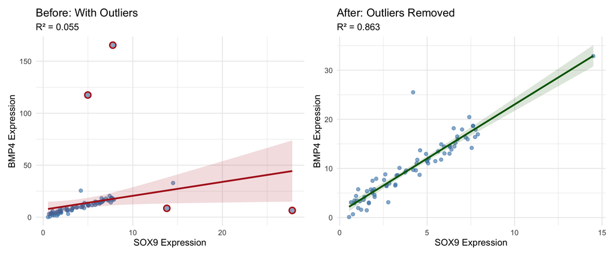

```r
p_raw <- ggplot(expr, aes(x = sox9_expression, y = bmp4_expression)) +
  geom_point(color = "steelblue", alpha = 0.6, size = 2) +
  geom_point(data = expr |> filter(sample_id %in% remove_ids),
             color = "firebrick", size = 3, shape = 1, stroke = 1.5) +
  geom_smooth(method = "lm", se = TRUE, color = "firebrick",
              fill = "firebrick", alpha = 0.15) +
  labs(x = "SOX9 Expression", y = "BMP4 Expression",
       title = "Before: With Outliers",
       subtitle = paste0("R² = ", round(summary(lm_expr_raw)$r.squared, 3))) +
  theme_minimal(base_size = 13)

p_clean <- ggplot(expr_clean, aes(x = sox9_expression, y = bmp4_expression)) +
  geom_point(color = "steelblue", alpha = 0.6, size = 2) +
  geom_smooth(method = "lm", se = TRUE, color = "darkgreen",
              fill = "darkgreen", alpha = 0.15) +
  labs(x = "SOX9 Expression", y = "BMP4 Expression",
       title = "After: Outliers Removed",
       subtitle = paste0("R² = ", round(summary(lm_expr_clean)$r.squared, 3))) +
  theme_minimal(base_size = 13)

p_raw + p_clean
```

- The side-by-side comparison dramatically illustrates how outliers can distort a regression analysis.
- The “Before” panel shows the outliers circled in red and a regression line pulled toward them, with a lower $R^2$.
- The “After” panel shows a tighter fit, higher $R^2$, and a regression line that better represents the majority of the data.

## Residual Diagnostics on Clean Data

- Output
- Code
- Interpretation

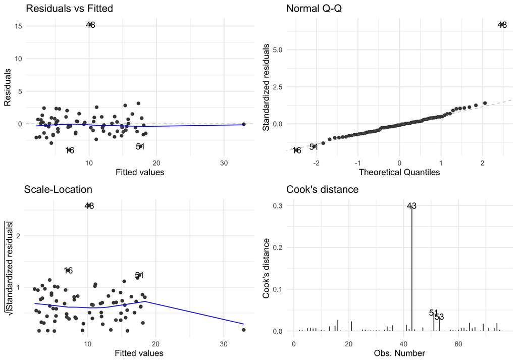

```r
autoplot(lm_expr_clean, which = 1:4, ncol = 2) +
  theme_minimal(base_size = 12)
```

- The diagnostic plots for the cleaned data should show well-behaved residuals – no systematic patterns, approximate normality, and constant variance.
- If the cleaned model passes all diagnostic checks, we can be confident in its coefficient estimates, standard errors, and p-values.
- Any remaining flagged observations in the cleaned data are likely natural biological variation rather than errors, and should generally be retained.

## Outlier Exercise Summary

**What We Learned**

1. **Always visualize your data first.** A simple scatterplot with labeled points would have immediately revealed the order-of-magnitude entry errors.
2. **Use multiple diagnostic tools.** Cook’s distance, leverage, and standardized residuals each capture different aspects of “outlierness.”
3. **Distinguish error from biology.** Data entry errors (10x values) are unambiguously wrong. Biological outliers require more thought — they could represent real variation, subpopulations, or experimental artifacts.
4. **Document everything.** Record which observations you removed, why, and how the results changed. Transparency is essential for reproducibility.
5. **Outlier removal can dramatically improve** $R^2$ **and coefficient estimates**, but it must be justified by evidence, not by a desire for better-looking results.

# The Eugenics History of Statistics

## Galton’s original data

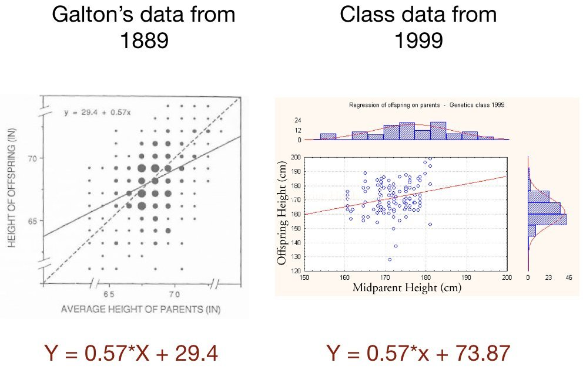

Source: Galton, F. (1889). *Natural Inheritance.* Macmillan; Class data from 1999.

## DRAFT: Galton’s Regression to the Mean

**Galton’s data from 1889**

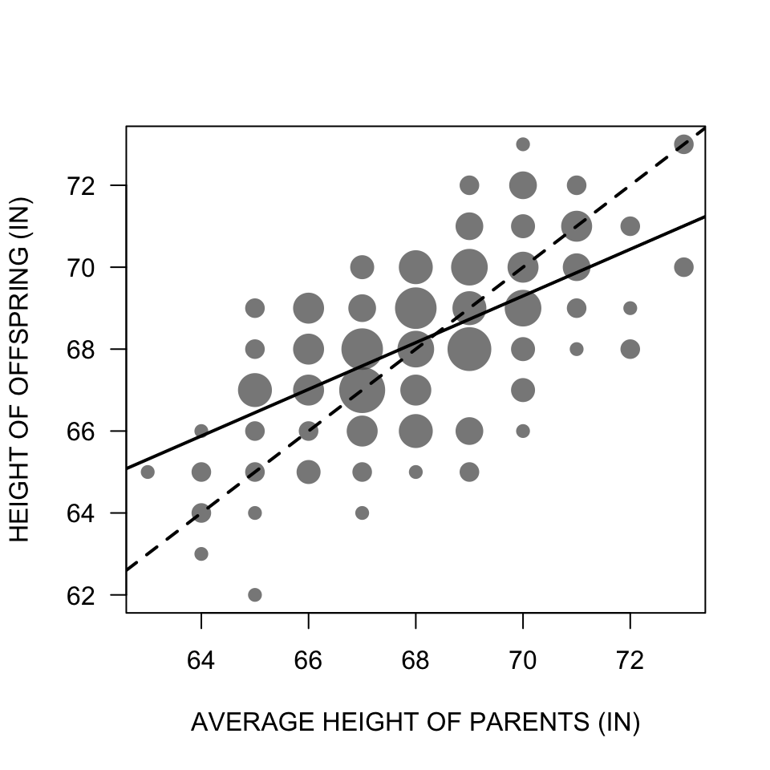

$$Y = 0.57X + 29.4$$

**Class data from 1999**

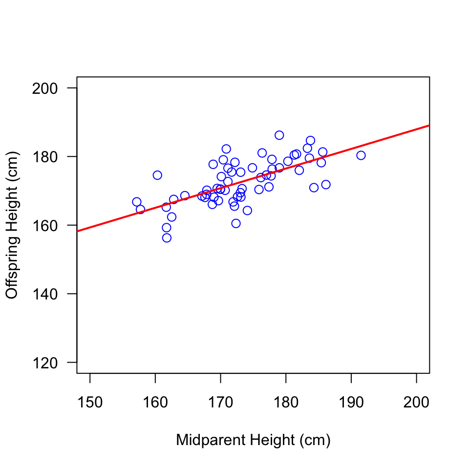

$$Y = 0.57x + 73.87$$

## Galton as the Father of Eugenics

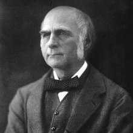

- Francis Galton: Darwin’s half cousin
- Studied human variation and genetic inheritance
  - Human height, fingerprints, intelligence
  - Correlation, regression toward the mean, and “nature versus nurture”
  - Pioneered twin studies

Source: Portrait of Sir Francis Galton, public domain.

## Galton as the Father of Eugenics

- Believed that intelligence was hereditary based on surveying prominent academics in Europe
- Used the ideas of **correlation** and **regression towards the mean** to argue that the upper class should breed amongst themselves to keep those “good genes” pure
- Wanted to provide monetary incentives for “good” couples to marry and reproduce as a way to avoid the upper class being genetically muddied by the lower class

- Competitions for the “perfect family” to encourage public consciousness and support for eugenics

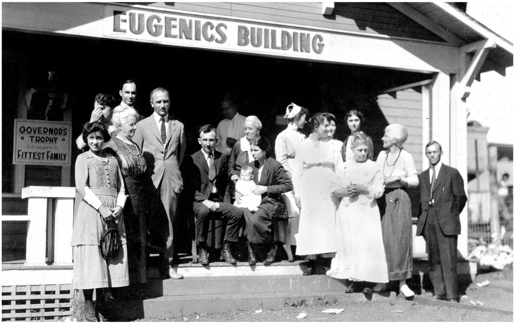

Source: Eugenics Building at a state fair, ca. 1920s. American Philosophical Society.

## Galton, Charles Davenport & G. Stanley Hall

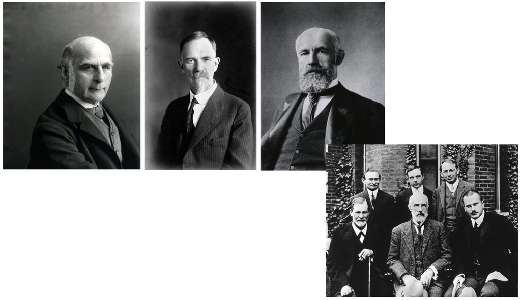

Source: Historical photographs, public domain.

## Logo of the US eugenics society

[figure not shown]

- American Eugenics Record Office (ERO) founded in Cold Springs Harbor

Source: Eugenics tree logo, American Eugenics Society, ca. 1920s. Public domain.

## Eugenics societies in America

- Advocated for state laws to ban interracial marriages and promote sterilization of “unfit” individuals (negative eugenics) - especially black, Latinx, and Native American women
- 30 states passed laws to force mental institution patients to be sterilized
- Between 1907 and 1963, over 64,000 individuals were forcibly sterilized under eugenic legislation in the United States

## RA Fisher and Eugenics in London

- Developer of Fishers exact test, analysis of variance (ANOVA), null hypothesis, p values, maximum likelihood, probability density functions
- Founding Chairman of the University of Cambridge Eugenics Society

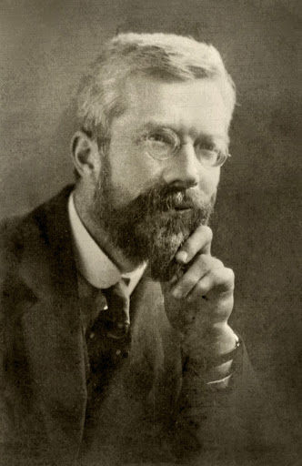

Source: Portrait of R.A. Fisher, public domain.

## RA Fisher and Eugenics

- 1/3rd of his work “The Genetical Theory of Natural Selection” discussed eugenics and his theory that the fall of civilizations was due to the fertility of their upper classes being diminished
- Used these statistical methods to test data on human variation to prove biological differences between human races
- Eugenics and racism were the primary motivators for many of these statistical tests that we use today

## A direct line to Hitler and Nazism

- Eugenics existed in America (and England) before it became popular in Germany.
- By 1933, California had subjected more people to forceful sterilization than all other U.S. states combined.
- The forced sterilization program engineered by the Nazis was partly inspired by California’s.

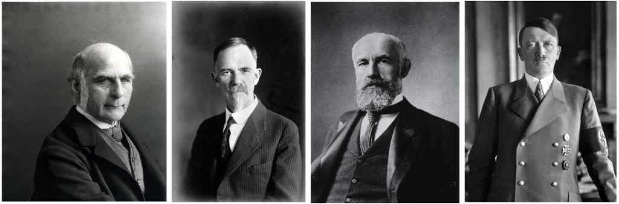

Source: Historical photographs, public domain.

## Sterilizations continue in America

- Our history books paint Nazi Germany as the primary evil of that time, while we try to cover up our significant role in eugenics
- It wasn’t until 1978 that the US passed regulations on sterilization procedures
- California only passed a bill to outlaw sterilization of inmates in 2014
- Certain members of the genetic engineering community threaten to bring back eugenics ideas
- Our current President repeats eugenics talking points

## So, what do we do from here?

- The statistical methods that Galton, Fisher, and others developed are useful science tools
- Important to use these tools for good - improving our planet, human health, and technology
- Important to acknowledge and not forget the history of science - educate others to avoid repeating history

## Interested in learning more?

[figure not shown]

- See also
  - “The Gene” by Siddhartha Mukherjee
  - “Control” by Adam Rutherford

Source: Zimmer, C. (2018). *She Has Her Mother’s Laugh.* Dutton.

# Polynomial Regression: When Linear Isn’t Enough

## Motivation for Polynomial Regression

The residual plots for the exercise model may suggest curvature — the loess smoother deviates from zero in a systematic way. This is a signal that the true relationship between exercise hours and grip strength may be nonlinear.

A polynomial regression extends the linear model by adding powers of $x$ as additional predictors. For a quadratic (degree 2) polynomial:

- Equation
- LaTeX
- Interpretation

$$y_i = \beta_0 + \beta_1 x_i + \beta_2 x_i^2 + \epsilon_i$$

```
y_i = \beta_0 + \beta_1 x_i + \beta_2 x_i^2 + \epsilon_i
```

- This extends the simple linear model by adding a squared term ($x_i^2$), allowing the relationship between Y and X to curve.
- It is still “linear” in the statistical sense because the parameters ($\beta_0$, $\beta_1$, $\beta_2$) enter linearly – it is the relationship with X that is nonlinear.
- A positive $\beta_2$ produces a U-shape; a negative $\beta_2$ produces an inverted-U (concave down).

This is still a **linear model** in the statistical sense (the parameters $\beta$ enter linearly), but the relationship between $y$ and $x$ is now curved. A quadratic term can capture a U-shape or inverted-U pattern that a straight line would miss.

## Power and Polynomial Relationships

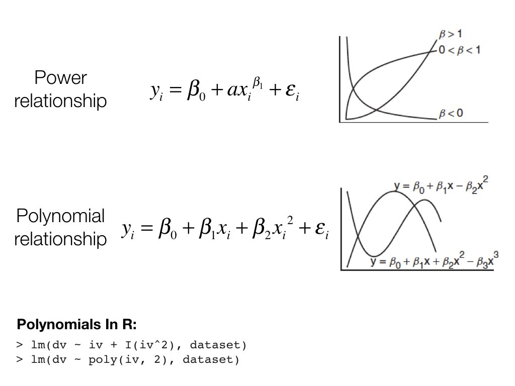

## Power and Polynomial Relationships (SVG)

[figure not shown]

## DRAFT: Power and Polynomial Relationships

**Power relationship:**

$$y_i = \beta_0 + ax_i^{\beta_1} + \varepsilon_i$$

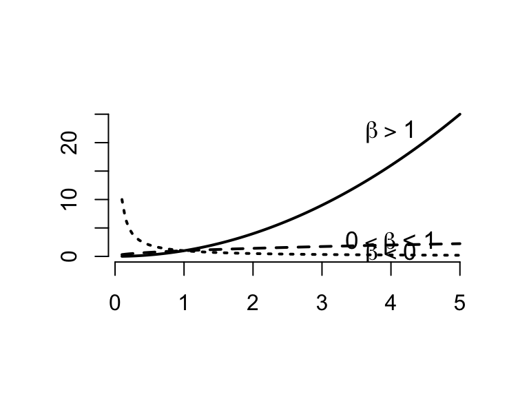

**Polynomial relationship:**

$$y_i = \beta_0 + \beta_1 x_i + \beta_2 x_i^2 + \varepsilon_i$$

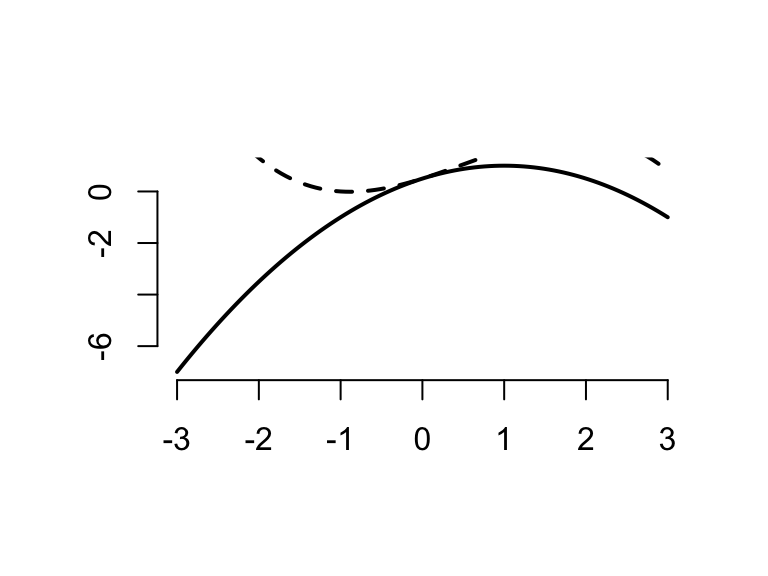

**Polynomials in R:**

```r
lm(dv ~ iv + I(iv^2), dataset)
lm(dv ~ poly(iv, 2), dataset)
```

In R, we use `poly(x, degree)` inside the `lm()` formula, or equivalently `I(x^2)`:

The `raw = TRUE` argument means R uses the raw polynomial terms ($x$ and $x^2$) rather than orthogonal polynomials, making the coefficients directly interpretable.

- Output
- Code
- Interpretation

```
Call:
lm(formula = grip_strength_kg ~ poly(exercise_hrs_week, 2, raw = TRUE),
    data = grip)

Residuals:
     Min       1Q   Median       3Q      Max
-13.9075  -3.8397   0.2455   4.2645  11.5638

Coefficients:
                                        Estimate Std. Error t value Pr(>|t|)
(Intercept)                             31.93561    1.05629  30.234  < 2e-16
poly(exercise_hrs_week, 2, raw = TRUE)1  2.21049    0.24837   8.900 3.66e-16
poly(exercise_hrs_week, 2, raw = TRUE)2 -0.11333    0.01235  -9.176  < 2e-16

(Intercept)                             ***
poly(exercise_hrs_week, 2, raw = TRUE)1 ***
poly(exercise_hrs_week, 2, raw = TRUE)2 ***
---
Signif. codes:  0 '***' 0.001 '**' 0.01 '*' 0.05 '.' 0.1 ' ' 1

Residual standard error: 5.34 on 197 degrees of freedom
Multiple R-squared:  0.2995,    Adjusted R-squared:  0.2924
F-statistic: 42.11 on 2 and 197 DF,  p-value: 5.921e-16
```

```r
# Fit quadratic polynomial: grip_strength ~ exercise + exercise^2
lm_exercise_poly <- lm(grip_strength_kg ~ poly(exercise_hrs_week, 2, raw = TRUE),
                        data = grip)
summary(lm_exercise_poly)
```

- The polynomial model adds a quadratic term ($\text{exercise}^2$) to capture potential curvature in the exercise-grip strength relationship.
- Using `poly(x, 2, raw = TRUE)` gives raw polynomial coefficients that are directly interpretable as the linear and quadratic effects.
- A significant quadratic term (p < 0.05) would confirm that the relationship is nonlinear and that the polynomial model is preferred over the simple linear one.

## Interpreting the Polynomial Model

Compare the $R^2$ from this polynomial model with the linear exercise model. If the quadratic term is significant and $R^2$ improves meaningfully, the curvilinear fit is more appropriate.

- Output
- Code
- Interpretation

| term | estimate | std.error | statistic | p.value |
| --- | --- | --- | --- | --- |
| (Intercept) | 31.9356 | 1.0563 | 30.2338 | 0 |
| poly(exercise_hrs_week, 2, raw = TRUE)1 | 2.2105 | 0.2484 | 8.9000 | 0 |
| poly(exercise_hrs_week, 2, raw = TRUE)2 | -0.1133 | 0.0123 | -9.1764 | 0 |

| r.squared | adj.r.squared | sigma | statistic | p.value | df | logLik | AIC | BIC | deviance | df.residual | nobs |
| --- | --- | --- | --- | --- | --- | --- | --- | --- | --- | --- | --- |
| 0.2995 | 0.2924 | 5.3401 | 42.1149 | 0 | 2 | -617.3264 | 1242.653 | 1255.846 | 5617.848 | 197 | 200 |

```r
tidy(lm_exercise_poly) |> kable(digits = 4)
glance(lm_exercise_poly) |> kable(digits = 4)
```

- Compare the $R^2$ from the polynomial model with the linear exercise model – a meaningful increase confirms the quadratic term improves the fit.
- The `tidy()` output shows whether the quadratic coefficient is statistically significant.
- If the quadratic term is significant but the $R^2$ improvement is modest, the practical significance may be limited.

## Comparing Linear vs. Polynomial Fit

We can formally compare the linear and polynomial models using `anova()`, which tests whether the additional quadratic term significantly improves the fit:

A significant p-value here means the quadratic term explains a statistically significant amount of additional variance beyond the linear term alone.

- Output
- Code
- Interpretation

```
Analysis of Variance Table

Model 1: grip_strength_kg ~ exercise_hrs_week
Model 2: grip_strength_kg ~ poly(exercise_hrs_week, 2, raw = TRUE)
  Res.Df    RSS Df Sum of Sq      F    Pr(>F)
1    198 8019.2
2    197 5617.8  1    2401.3 84.207 < 2.2e-16 ***
---
Signif. codes:  0 '***' 0.001 '**' 0.01 '*' 0.05 '.' 0.1 ' ' 1
```

```r
# Compare nested models: linear vs. quadratic
anova(lm_exercise, lm_exercise_poly)
```

- The `anova()` comparison performs a formal F-test of whether the quadratic term significantly improves the model over the linear-only version.
- A significant p-value means the additional variance explained by the quadratic term is unlikely to have occurred by chance.
- This nested model comparison is the proper way to test whether increased model complexity is justified.

## Visualizing the Polynomial Fit

- Output
- Code
- Interpretation

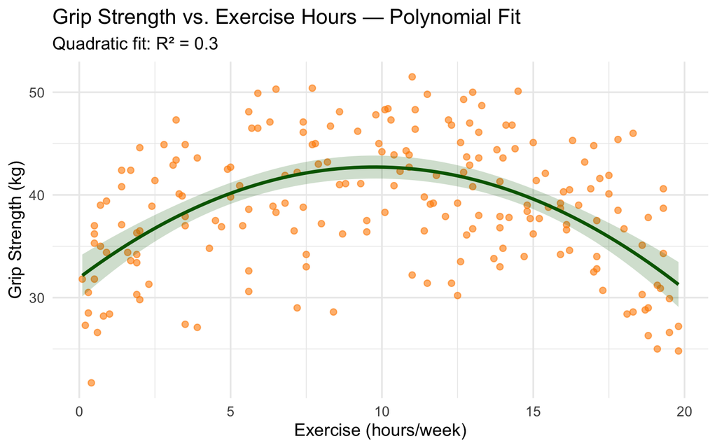

```r
ggplot(grip, aes(x = exercise_hrs_week, y = grip_strength_kg)) +
  geom_point(color = "darkorange", alpha = 0.6, size = 2) +
  geom_smooth(method = "lm", formula = y ~ poly(x, 2),
              se = TRUE, color = "darkgreen", fill = "darkgreen", alpha = 0.2) +
  labs(
    x = "Exercise (hours/week)",
    y = "Grip Strength (kg)",
    title = "Grip Strength vs. Exercise Hours — Polynomial Fit",
    subtitle = paste0("Quadratic fit: R² = ",
                      round(summary(lm_exercise_poly)$r.squared, 3))
  ) +
  theme_minimal(base_size = 14)
```

- The polynomial fit shows a curved relationship between exercise hours and grip strength, capturing a pattern the linear model missed.
- The curve may reveal an optimal range of exercise – too little or too much might not improve grip strength as much as moderate amounts.
- Compare the $R^2$ of this fit with the linear model to quantify the improvement.

## Linear vs. Polynomial: Side by Side

- Output
- Code
- Interpretation

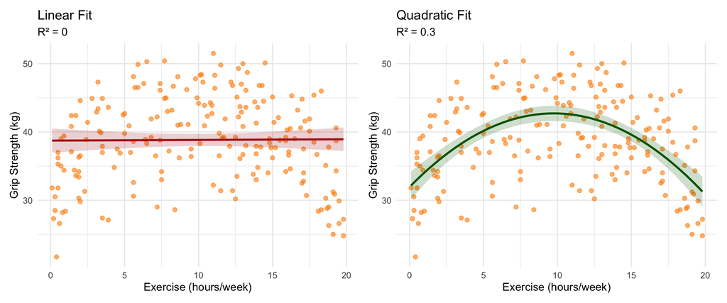

```r
p_lin <- ggplot(grip, aes(x = exercise_hrs_week, y = grip_strength_kg)) +
  geom_point(color = "darkorange", alpha = 0.6, size = 2) +
  geom_smooth(method = "lm", se = TRUE, color = "firebrick",
              fill = "firebrick", alpha = 0.2) +
  labs(x = "Exercise (hours/week)", y = "Grip Strength (kg)",
       title = "Linear Fit",
       subtitle = paste0("R² = ", round(summary(lm_exercise)$r.squared, 3))) +
  theme_minimal(base_size = 13)

p_poly <- ggplot(grip, aes(x = exercise_hrs_week, y = grip_strength_kg)) +
  geom_point(color = "darkorange", alpha = 0.6, size = 2) +
  geom_smooth(method = "lm", formula = y ~ poly(x, 2),
              se = TRUE, color = "darkgreen", fill = "darkgreen", alpha = 0.2) +
  labs(x = "Exercise (hours/week)", y = "Grip Strength (kg)",
       title = "Quadratic Fit",
       subtitle = paste0("R² = ", round(summary(lm_exercise_poly)$r.squared, 3))) +
  theme_minimal(base_size = 13)

p_lin + p_poly
```

- Side-by-side comparison makes the improvement from the linear to quadratic fit visually apparent.
- The polynomial fit (green) curves through the data, while the linear fit (red) misses the nonlinear pattern.
- The $R^2$ values in the subtitles quantify how much additional variance the quadratic term explains.

## Residuals: Linear vs. Polynomial Exercise Model

Now we compare the residual plots to see whether the polynomial model resolves the curvature issue:

- Output
- Code
- Interpretation

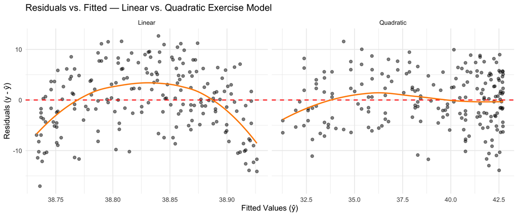

```r
lin_diag <- data.frame(
  fitted = fitted(lm_exercise),
  residuals = residuals(lm_exercise),
  model = "Linear"
)

poly_diag <- data.frame(
  fitted = fitted(lm_exercise_poly),
  residuals = residuals(lm_exercise_poly),
  model = "Quadratic"
)

both_diag <- rbind(lin_diag, poly_diag)

ggplot(both_diag, aes(x = fitted, y = residuals)) +
  geom_point(alpha = 0.5, size = 2) +
  geom_hline(yintercept = 0, linetype = "dashed", color = "red", linewidth = 0.8) +
  geom_smooth(method = "loess", se = FALSE, color = "darkorange", linewidth = 1) +
  facet_wrap(~ model, scales = "free_x") +
  labs(x = "Fitted Values (ŷ)", y = "Residuals (y - ŷ)",
       title = "Residuals vs. Fitted — Linear vs. Quadratic Exercise Model") +
  theme_minimal(base_size = 13)
```

- Comparing residual patterns between the linear and quadratic models reveals whether the polynomial term resolved the curvature issue.
- In the linear model, the loess smoother should show a curved pattern; in the quadratic model, it should be flatter (closer to zero).
- A flatter loess smoother in the polynomial residuals confirms that the quadratic term successfully captured the nonlinear component of the relationship.

## Full Diagnostics: Polynomial Exercise Model

- Output
- Code
- Interpretation

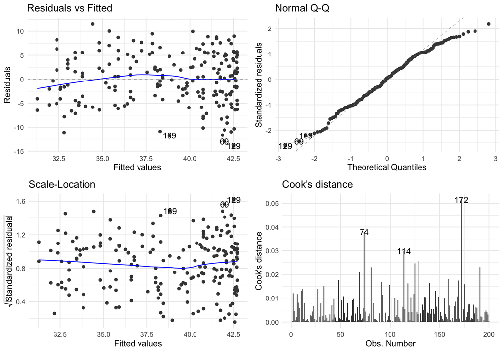

```r
autoplot(lm_exercise_poly, which = 1:4, ncol = 2) +
  theme_minimal(base_size = 12)
```

- After fitting the polynomial model, the residual diagnostics should show improved patterns compared to the linear exercise model.
- Look for the Residuals vs. Fitted plot showing a more random scatter (less curvature), confirming the quadratic term addresses the nonlinearity.
- The Q-Q plot should still show approximate normality, and the Scale-Location plot should show constant variance.

## Case Study in Model Selection: Beetle Horn Allometry

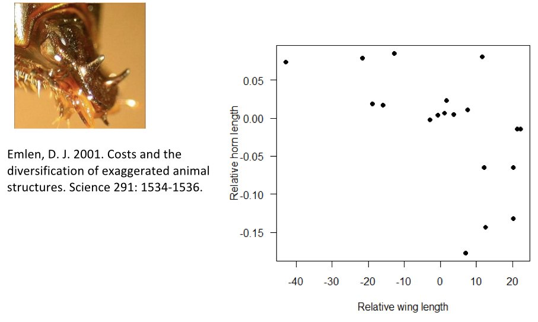

Emlen 2001 beetle horn vs wing length data

Data from Emlen, D.J. 2001. *Costs and the diversification of exaggerated animal structures.* Science 291: 1534-1536.

Source: Emlen, D.J. (2001). Costs and the diversification of exaggerated animal structures. *Science*, 291, 1534-1536.

## DRAFT: Beetle Horn Allometry Data

- Output
- Code
- Interpretation

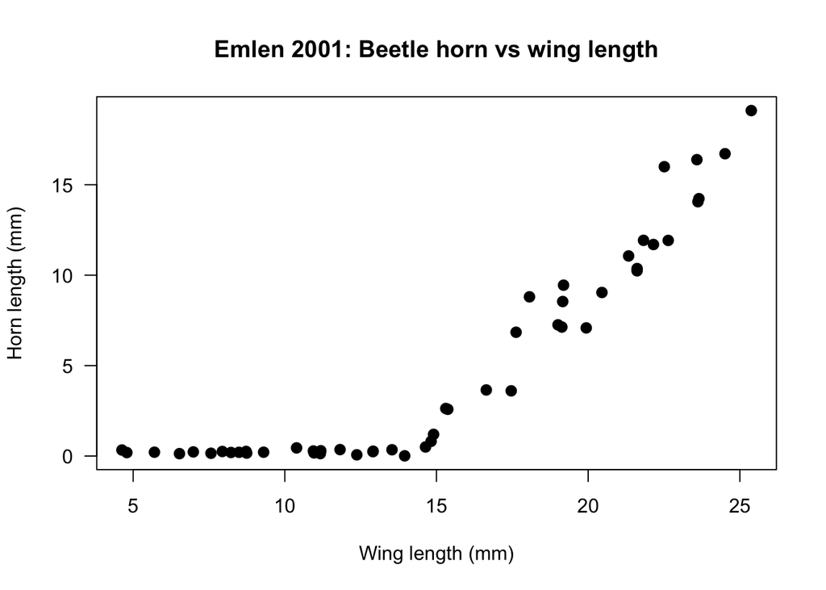

```r
# Simulate beetle horn vs wing data similar to Emlen 2001
set.seed(2001)
wing <- seq(5, 25, length.out = 50) + rnorm(50, 0, 1)
horn <- ifelse(wing < 15, rnorm(50, 0, 0.5),
               0.8 * (wing - 14)^1.3 + rnorm(50, 0, 1.5))
horn[horn < 0] <- abs(rnorm(sum(horn < 0), 0.2, 0.1))
beetle <- data.frame(wing = wing, horn = horn)

plot(beetle$wing, beetle$horn, pch = 16, cex = 1.3,
     xlab = "Wing length (mm)", ylab = "Horn length (mm)",
     main = "Emlen 2001: Beetle horn vs wing length", las = 1)
```

- The scatterplot reveals a clear nonlinear (threshold-like) pattern: beetles with small wings have essentially no horn growth, while larger beetles show rapid, accelerating horn growth.
- This is a classic allometric relationship where resource allocation to horns depends on body size exceeding a developmental threshold.
- A simple linear model would be inappropriate here; polynomial or piecewise regression is needed to capture this pattern.

## Linear Regression Fit

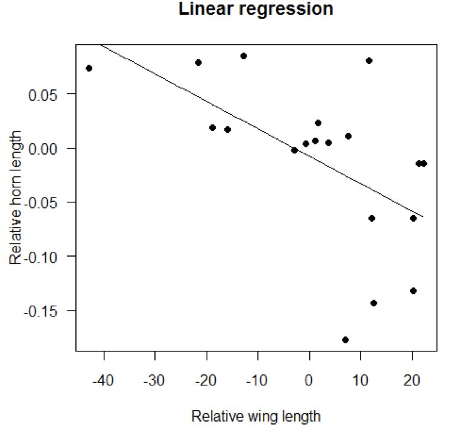

Linear regression on beetle data

Source: Data from Emlen, D.J. (2001). *Science*, 291, 1534-1536.

## DRAFT: Linear Fit

- Output
- Code
- Interpretation

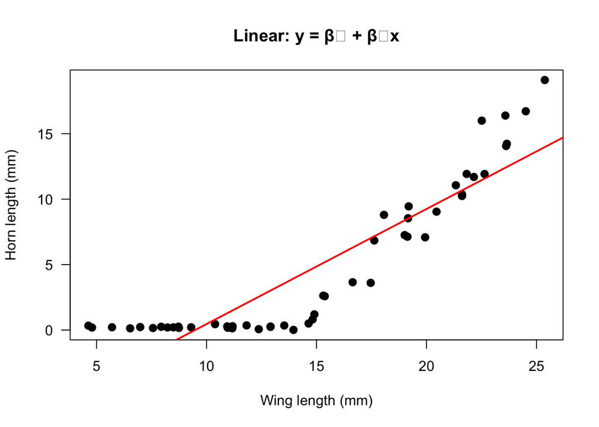

```r
plot(beetle$wing, beetle$horn, pch = 16, cex = 1.3,
     xlab = "Wing length (mm)", ylab = "Horn length (mm)",
     main = "Linear: y = β₀ + β₁x", las = 1)
fit1 <- lm(horn ~ wing, data = beetle)
abline(fit1, lwd = 2, col = "red")
```

- A simple linear fit to the beetle horn data shows a positive trend but clearly misses the nonlinear pattern.
- The line underpredicts horn length for very large beetles and overpredicts for mid-sized beetles, suggesting a curved relationship.
- This motivates exploring polynomial regression to better capture the allometric growth pattern.

## Quadratic Regression Fit

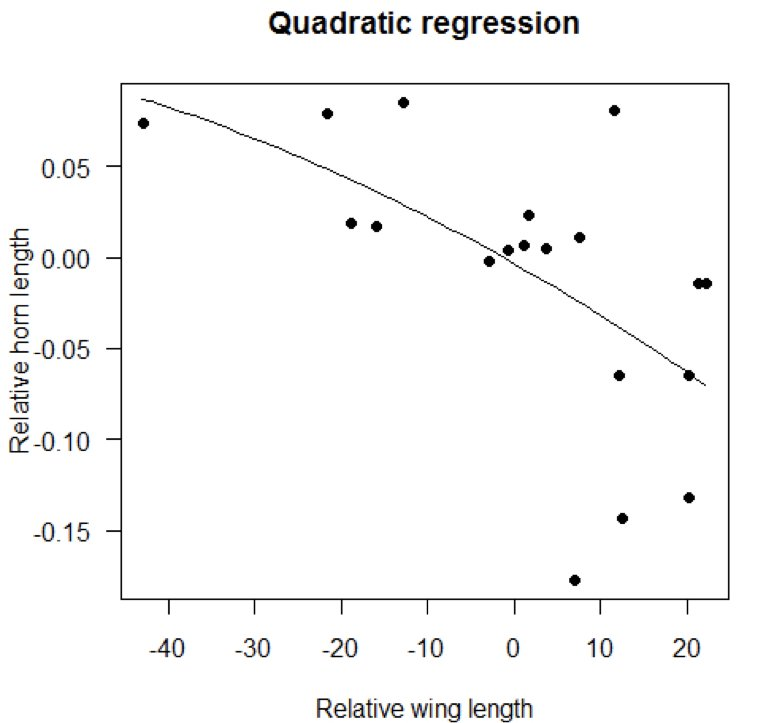

Quadratic (polynomial degree 2) regression

Source: Data from Emlen, D.J. (2001). *Science*, 291, 1534-1536.

## DRAFT: Quadratic Fit

- Output
- Code
- Interpretation

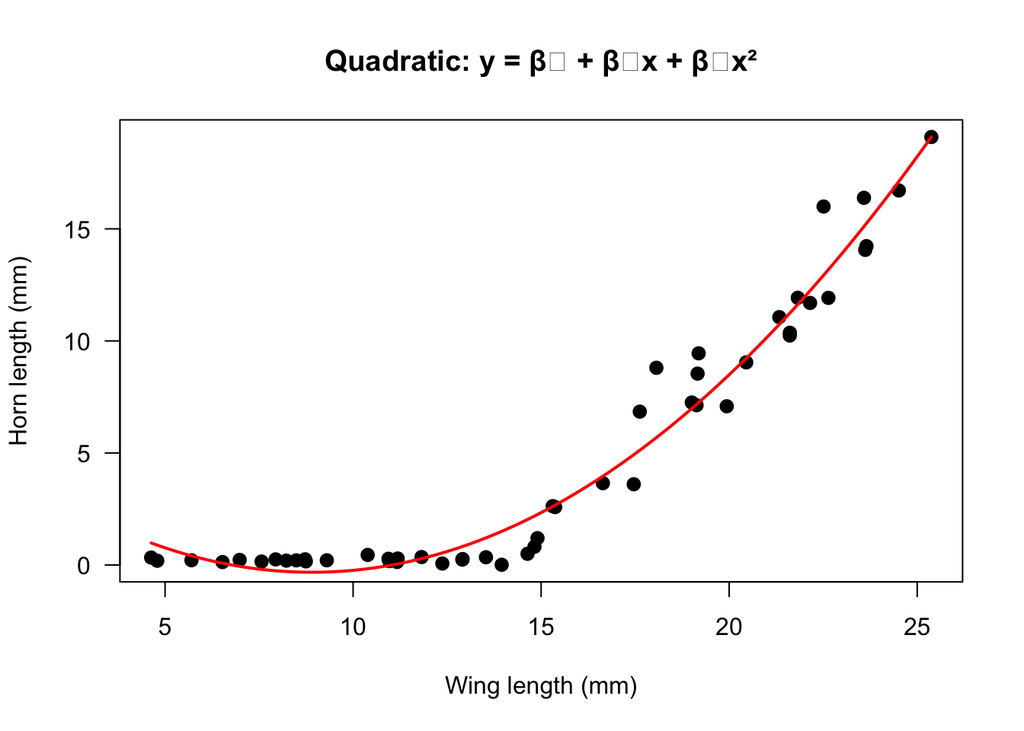

```r
plot(beetle$wing, beetle$horn, pch = 16, cex = 1.3,
     xlab = "Wing length (mm)", ylab = "Horn length (mm)",
     main = "Quadratic: y = β₀ + β₁x + β₂x²", las = 1)
fit2 <- lm(horn ~ poly(wing, 2, raw = TRUE), data = beetle)
xseq <- seq(min(beetle$wing), max(beetle$wing), length.out = 200)
lines(xseq, predict(fit2, newdata = data.frame(wing = xseq)),
      lwd = 2, col = "red")
```

- The quadratic fit captures the nonlinear relationship between wing length and horn length, showing an accelerating pattern.
- This is biologically plausible: horn growth may be disproportionately allocated in larger beetles (allometric scaling).
- The curve fits the data much better than the linear model, particularly at the extremes of wing length.

## Cubic Regression Fit

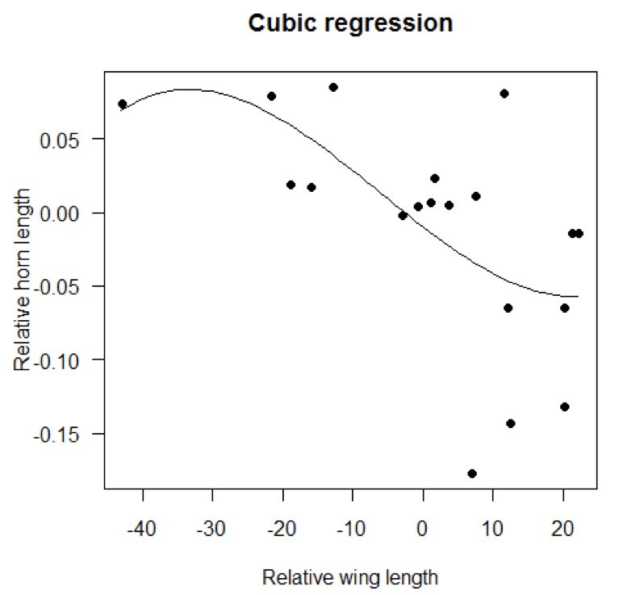

Cubic (polynomial degree 3) regression

Source: Data from Emlen, D.J. (2001). *Science*, 291, 1534-1536.

## DRAFT: Cubic Fit

- Output
- Code
- Interpretation

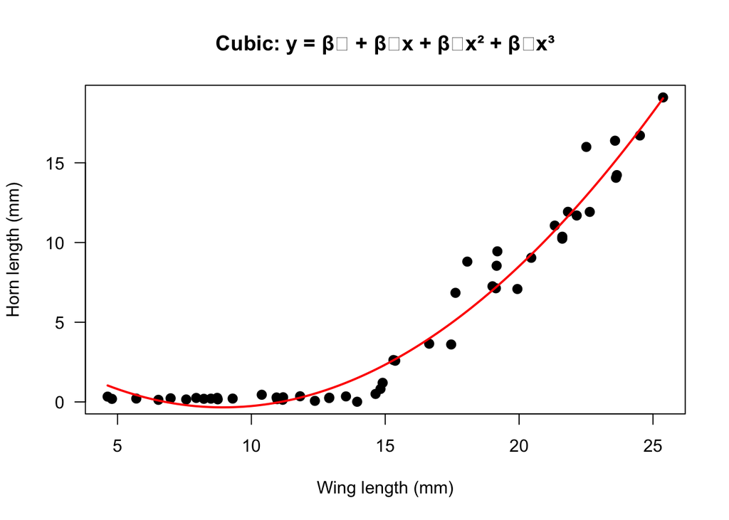

```r
plot(beetle$wing, beetle$horn, pch = 16, cex = 1.3,
     xlab = "Wing length (mm)", ylab = "Horn length (mm)",
     main = "Cubic: y = β₀ + β₁x + β₂x² + β₃x³", las = 1)
fit3 <- lm(horn ~ poly(wing, 3, raw = TRUE), data = beetle)
xseq <- seq(min(beetle$wing), max(beetle$wing), length.out = 200)
lines(xseq, predict(fit3, newdata = data.frame(wing = xseq)),
      lwd = 2, col = "red")
```

## Higher-Order Polynomials

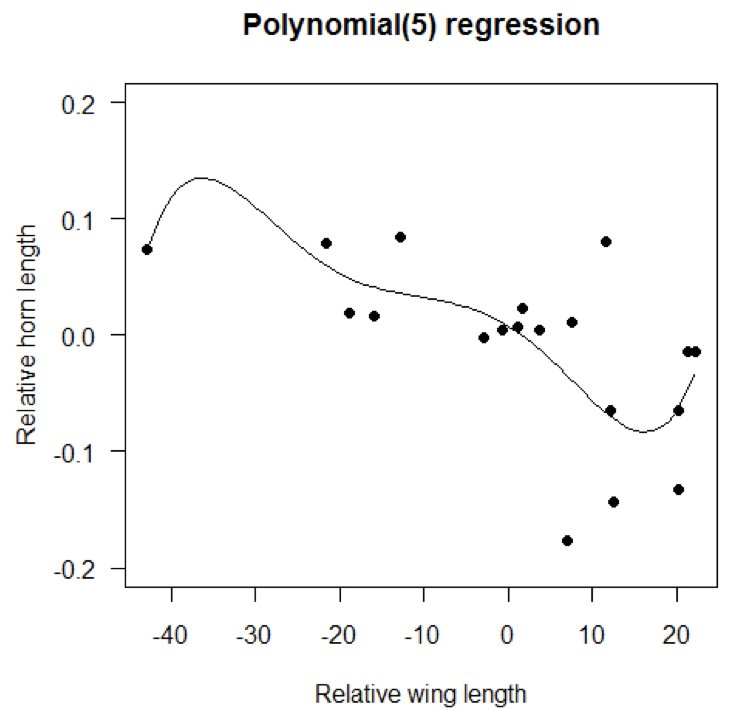

Polynomial degree 5 regression

Source: Data from Emlen, D.J. (2001). *Science*, 291, 1534-1536.

## DRAFT: Degree 5 Polynomial

- Output
- Code
- Interpretation

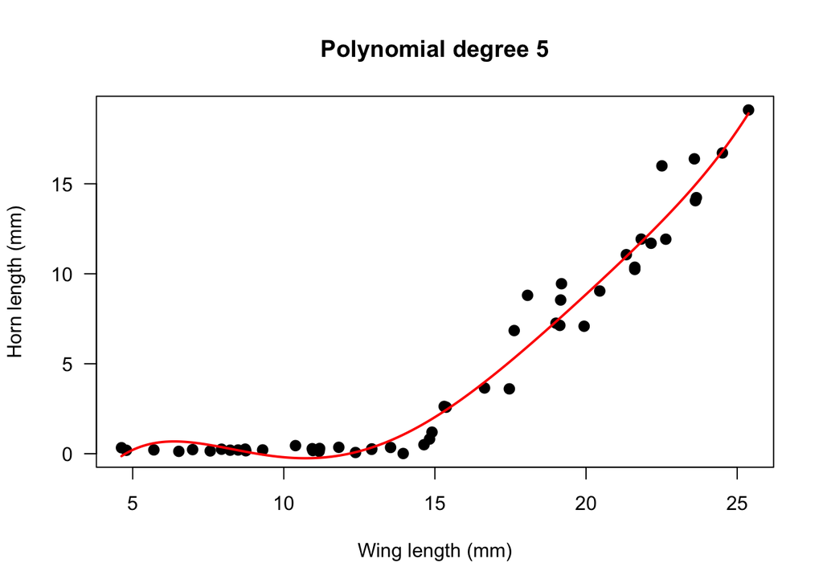

```r
plot(beetle$wing, beetle$horn, pch = 16, cex = 1.3,
     xlab = "Wing length (mm)", ylab = "Horn length (mm)",
     main = "Polynomial degree 5", las = 1)
fit5 <- lm(horn ~ poly(wing, 5, raw = TRUE), data = beetle)
xseq <- seq(min(beetle$wing), max(beetle$wing), length.out = 200)
lines(xseq, predict(fit5, newdata = data.frame(wing = xseq)),
      lwd = 2, col = "red")
```

- A degree-5 polynomial begins to show signs of overfitting, with the curve starting to follow individual data points rather than the overall trend.
- While this may fit the training data better than a quadratic, the additional flexibility risks capturing noise rather than biological signal.
- Compare the shape of this curve with the quadratic and cubic fits to judge whether the extra terms add meaningful improvement.

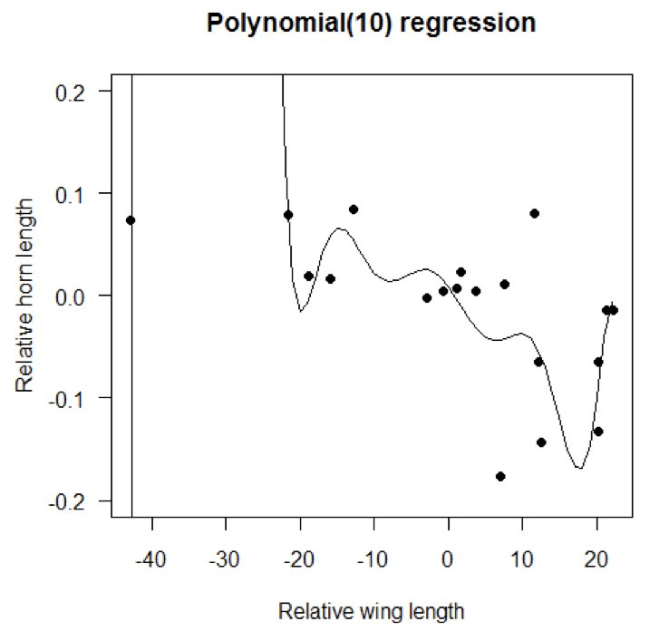

Polynomial degree 10 regression - overfitting!

Source: Data from Emlen, D.J. (2001). *Science*, 291, 1534-1536.

## DRAFT: Degree 10 Polynomial - Overfitting!

- Output
- Code
- Interpretation

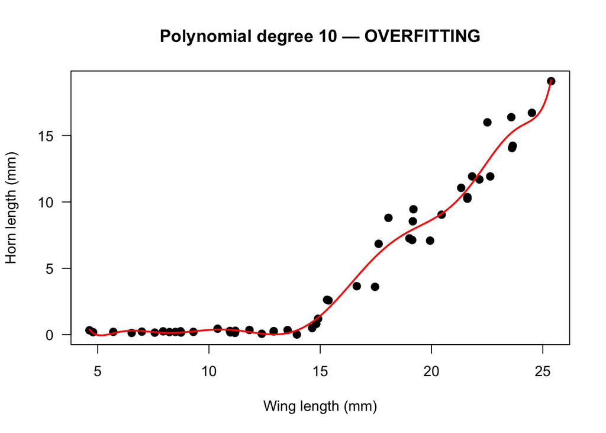

```r
plot(beetle$wing, beetle$horn, pch = 16, cex = 1.3,
     xlab = "Wing length (mm)", ylab = "Horn length (mm)",
     main = "Polynomial degree 10 — OVERFITTING", las = 1)
fit10 <- lm(horn ~ poly(wing, 10, raw = TRUE), data = beetle)
xseq <- seq(min(beetle$wing), max(beetle$wing), length.out = 200)
lines(xseq, predict(fit10, newdata = data.frame(wing = xseq)),
      lwd = 2, col = "red")
```

## Model Selection Visualization

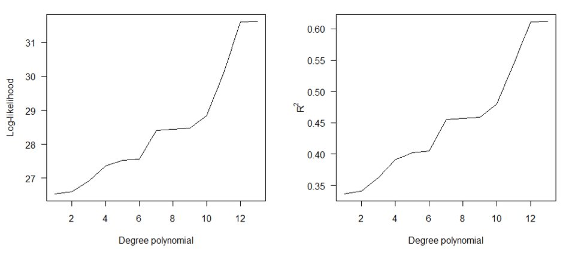

Log-likelihood and R² vs polynomial degree

Source: Data from Emlen, D.J. (2001). *Science*, 291, 1534-1536.

## DRAFT: Model Selection - Log-Likelihood and R²

- Output
- Code
- Interpretation

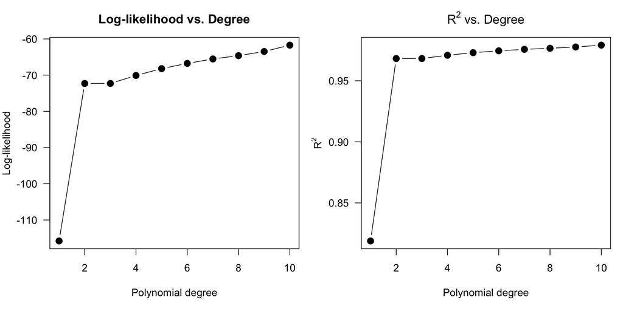

```r
degrees <- 1:10
loglik <- sapply(degrees, function(d) {
  fit <- lm(horn ~ poly(wing, d, raw = TRUE), data = beetle)
  logLik(fit)
})
r2 <- sapply(degrees, function(d) {
  fit <- lm(horn ~ poly(wing, d, raw = TRUE), data = beetle)
  summary(fit)$r.squared
})

par(mfrow = c(1, 2), mar = c(5, 4, 3, 1))
plot(degrees, loglik, type = "b", pch = 16, cex = 1.5,
     xlab = "Polynomial degree", ylab = "Log-likelihood",
     main = "Log-likelihood vs. Degree", las = 1)
plot(degrees, r2, type = "b", pch = 16, cex = 1.5,
     xlab = "Polynomial degree", ylab = expression(R^2),
     main = expression(R^2 * " vs. Degree"), las = 1)
```

- Both log-likelihood and $R^2$ increase with polynomial degree, but the gains diminish after degree 2-3.
- The flattening of the curves indicates that additional polynomial terms add complexity without meaningfully improving fit – a sign of overfitting.
- Model selection criteria like AIC, BIC, or Mallow’s $C_p$ penalize complexity to identify the point where adding more terms is no longer justified.

## Mallow’s Cp Statistic

$$C_p = \frac{SS_{\text{error}}}{\hat{\sigma}^2} - n + 2p$$

- $SS_{\text{error}}$: error sum of squares for the model with $p$ predictors (incl. intercept)
- $\hat{\sigma}^2$: error mean square of full model (e.g., all predictors)
- $n$: sample size
- $p$: number of predictors (including intercept)

$C_p$ estimates mean square prediction error. (Related to AIC.)

$2p$: sort of a penalty for including too many predictors. A feature shared with all other model selection criteria.

A model with $C_p \approx p$ fits well without overfitting. Models with $C_p \gg p$ underfit; those with minimum $C_p$ are preferred.

**Summary**

1. **Always plot residuals** after fitting a model. The summary statistics ($R^2$, p-values) alone are not sufficient.
2. A poor residual pattern does not mean your data are bad — it means **your model needs improvement**. Consider transformations, polynomial terms, or different model families.
3. The BMP2 cream model shows a clear linear relationship with well-behaved residuals.
4. The exercise model shows that forcing a linear fit on a potentially nonlinear relationship produces misleading residuals. Adding a quadratic term can resolve this.
5. **Model selection is iterative**: fit, diagnose, improve, repeat.

# Model I vs Model II Regression

## When to Use Model II Regression

**Model I (OLS) Regression:**

- Assumes predictor X is measured **without error**
- Y contains all the measurement error
- Standard `lm()` in R

**Model II Regression:**

- Both X and Y have **measurement error**
- Neither variable is controlled/fixed
- Use when both variables are random measurements

**Note**

Use Model II when both X and Y are biological measurements (e.g., body size vs organ size, two gene expression levels).

## Model II Regression Methods

| Method | Abbreviation | Description |
| --- | --- | --- |
| **Major Axis** | MA | Minimizes perpendicular distances |
| **Standard Major Axis** | SMA | Geometric mean regression |
| **Ranged Major Axis** | RMA | Accounts for range differences |
| **Ordinary Least Squares** | OLS | Standard regression (for comparison) |

## Types of Linear Regression

Not all regression is created equal! The choice depends on **measurement error**:

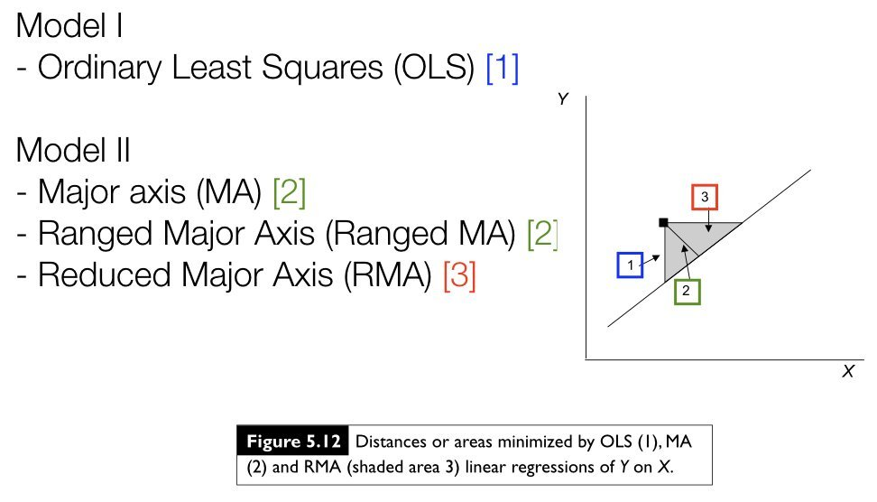

Model I (OLS) vs Model II regression types

Source: Figure 5.12, Logan, M. (2010). *Biostatistical Design and Analysis Using R.* Wiley-Blackwell.

## Types of Linear Regression (SVG)

[figure not shown]

## DRAFT: Model I vs Model II Regression

- Output
- Code
- Interpretation

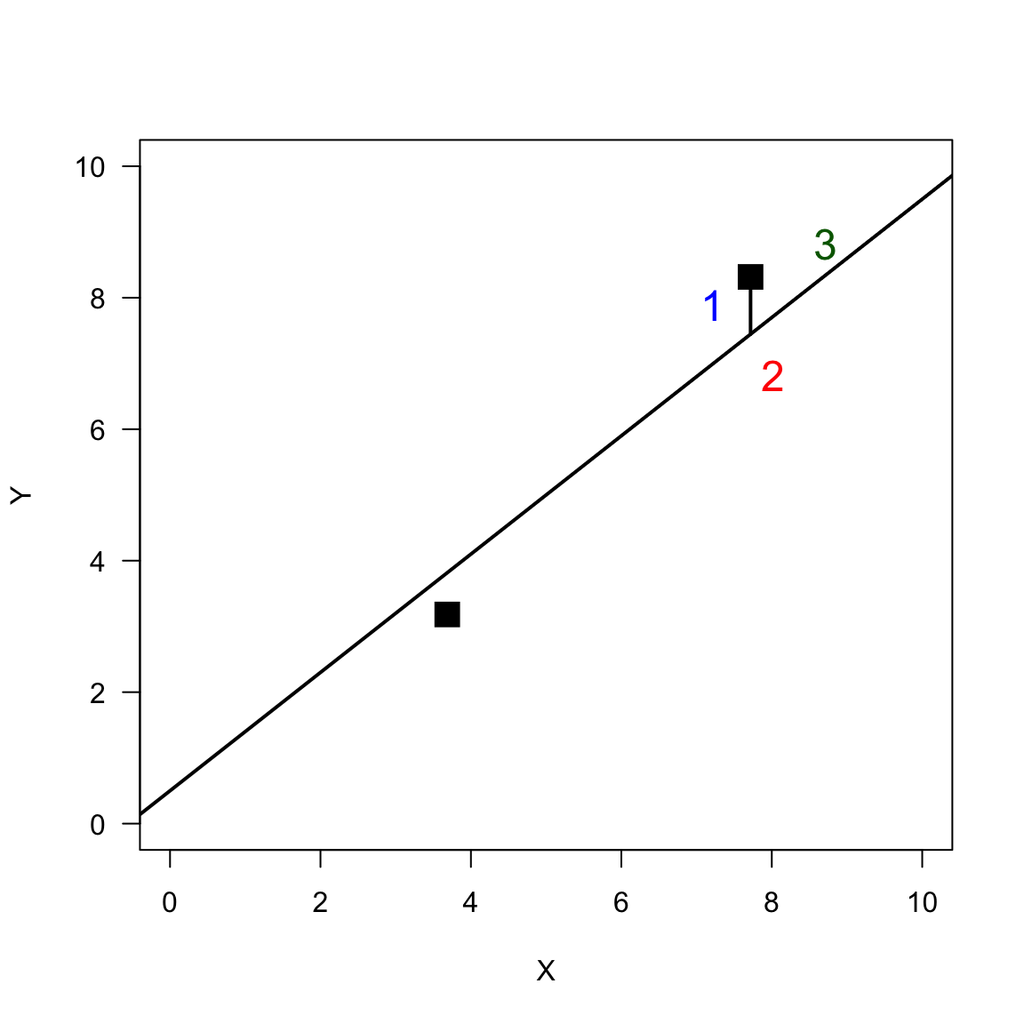

```r
set.seed(42)
x <- rnorm(2, c(3, 8), c(0.5, 0.5))
y <- rnorm(2, c(3, 8), c(0.5, 0.5))

plot(x, y, pch = 15, cex = 2, xlim = c(0, 10), ylim = c(0, 10),
     xlab = "X", ylab = "Y", las = 1, main = "")
abline(a = 0.5, b = 0.9, lwd = 2)
segments(x[2], y[2], x[2], 0.5 + 0.9 * x[2], lwd = 2, lty = 1)
text(x[2] - 0.5, (y[2] + 0.5 + 0.9 * x[2]) / 2, "1", cex = 1.5, col = "blue")
text(x[2] + 1, y[2] + 0.5, "3", cex = 1.5, col = "darkgreen")
text(x[2] + 0.3, y[2] - 1.5, "2", cex = 1.5, col = "red")
```

**Model I** — Ordinary Least Squares (OLS) [1]: minimizes vertical distances

**Model II** — Major axis (MA) [2]: minimizes perpendicular distances; Reduced Major Axis (RMA) [3]: minimizes area of triangles

## Regression Type Examples

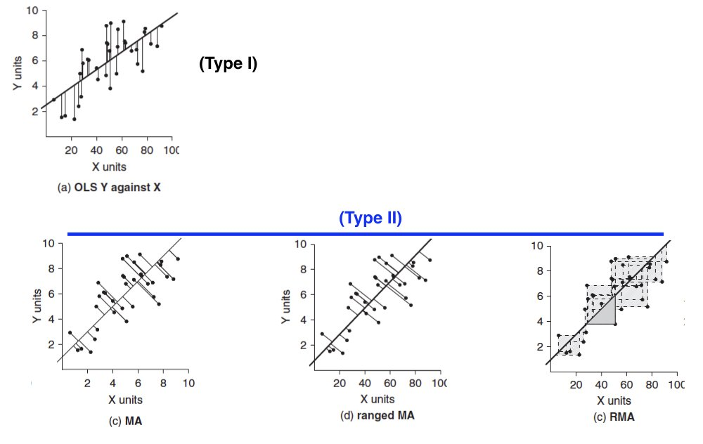

Comparison of OLS (Type I) and Type II regression methods

Source: Logan, M. (2010). *Biostatistical Design and Analysis Using R.* Wiley-Blackwell.

## DRAFT: OLS, MA, and RMA Comparison

- Output
- Code
- Interpretation

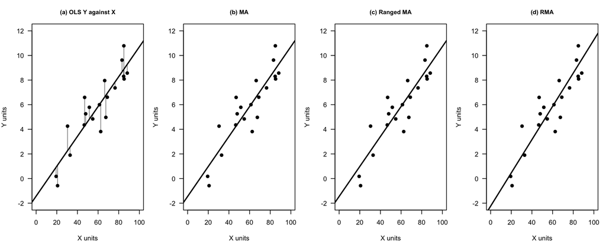

```r
set.seed(42)
n <- 20
x <- runif(n, 10, 90)
y <- 0.1 * x + rnorm(n, 0, 1)

par(mfrow = c(1, 4), mar = c(4, 4, 3, 1))

# (a) OLS Y on X
plot(x, y, pch = 16, cex = 1.2, xlab = "X units", ylab = "Y units",
     main = "(a) OLS Y against X", cex.main = 0.9, las = 1, xlim = c(0, 100), ylim = c(-2, 12))
fit_ols <- lm(y ~ x)
abline(fit_ols, lwd = 2)
segments(x, fitted(fit_ols), x, y, lwd = 0.5)

# (b) MA
plot(x, y, pch = 16, cex = 1.2, xlab = "X units", ylab = "Y units",
     main = "(b) MA", cex.main = 0.9, las = 1, xlim = c(0, 100), ylim = c(-2, 12))
sx <- sd(x); sy <- sd(y)
slope_ma <- (sy^2 - sx^2 + sqrt((sy^2 - sx^2)^2 + 4 * cov(x,y)^2)) / (2 * cov(x,y))
int_ma <- mean(y) - slope_ma * mean(x)
abline(a = int_ma, b = slope_ma, lwd = 2)

# (c) Ranged MA
plot(x, y, pch = 16, cex = 1.2, xlab = "X units", ylab = "Y units",
     main = "(c) Ranged MA", cex.main = 0.9, las = 1, xlim = c(0, 100), ylim = c(-2, 12))
abline(a = int_ma, b = slope_ma, lwd = 2)

# (d) RMA
plot(x, y, pch = 16, cex = 1.2, xlab = "X units", ylab = "Y units",
     main = "(d) RMA", cex.main = 0.9, las = 1, xlim = c(0, 100), ylim = c(-2, 12))
slope_rma <- sign(cor(x, y)) * sy / sx
int_rma <- mean(y) - slope_rma * mean(x)
abline(a = int_rma, b = slope_rma, lwd = 2)
```

## When to Use Each Model Type

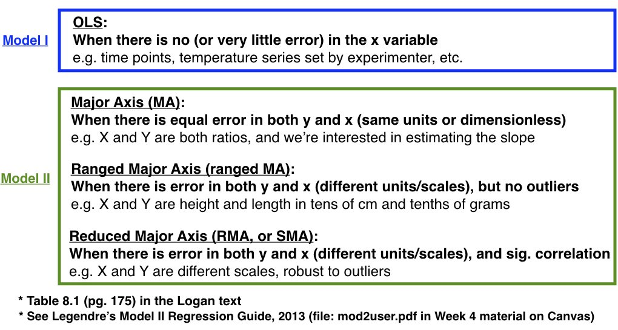

Guidelines for choosing between OLS, MA, and RMA regression

Source: Table 8.1, Logan, M. (2010). *Biostatistical Design and Analysis Using R.* Wiley-Blackwell; Legendre, P. (2013). Model II Regression Guide.

## When to Use Each Model Type (SVG)

[figure not shown]

## DRAFT: When to Use Each Regression Type

|  | **Method** | **When to use** | **Example** |
| --- | --- | --- | --- |
| **Model I** | **OLS** | No (or very little) error in x variable | Time points, temperature set by experimenter |
| **Model II** | **Major Axis (MA)** | Equal error in both y and x (same units or dimensionless) | X and Y are both ratios; interested in estimating slope |
|  | **Ranged MA** | Error in both y and x (different units/scales), no outliers | Height in cm and length in tenths of grams |
|  | **Reduced MA (RMA, SMA)** | Error in both y and x (different scales), significant correlation | X and Y are different scales, robust to outliers |

*Table 8.1 (pg. 175) in the Logan text. See also Legendre’s Model II Regression Guide, 2013.*

## Model II Regression with lmodel2

- Code
- Interpretation

```r
library(lmodel2)

# Model II regression when both X and Y have measurement error
# Example: comparing two measurement methods
mod2 <- lmodel2(Y ~ X, data = mydata, range.y = "relative", range.x = "relative")

# Returns OLS, MA, SMA (RMA), and ranged major axis results
summary(mod2)
plot(mod2)
```

- The `lmodel2()` function fits four regression methods simultaneously: OLS, Major Axis, Standard Major Axis (SMA/RMA), and Ranged Major Axis.
- Setting `range.y = "relative"` and `range.x = "relative"` tells the function to standardize variables by their ranges, which is appropriate when X and Y have different units or scales.
- The `plot()` method visualizes all regression lines together, making it easy to see how much the slope estimates differ across methods.

**Note**

Use Model II regression when: - Both variables have measurement error - Neither variable is experimentally controlled - You’re comparing methods or studying allometry

## Model II Regression in R

- Code
- Interpretation

```r
# Install and load lmodel2 package
# install.packages("lmodel2")
library(lmodel2)

# Fit Model II regression
model2_result <- lmodel2(y ~ x, data = mydata)

# View results - provides OLS, MA, and SMA estimates
model2_result

# Plot with different regression lines
plot(mydata$x, mydata$y, pch = 19)
abline(model2_result$regression.results[2, 2],  # MA intercept
       model2_result$regression.results[2, 3],  # MA slope
       col = "blue", lty = 2)
abline(model2_result$regression.results[3, 2],  # SMA intercept
       model2_result$regression.results[3, 3],  # SMA slope
       col = "red", lty = 3)
```

- This code fits a Model II regression using `lmodel2()`, which simultaneously estimates OLS, MA, and SMA regression lines.
- The plot overlays the Major Axis (blue dashed) and Standard Major Axis (red dotted) regression lines on the scatterplot, allowing visual comparison of the different methods.
- SMA (Reduced Major Axis) is the most commonly used Model II method in biology; MA is preferred when both variables are in the same units.

## Choosing Between Model I and II

**Decision Guide**

Use **Model I (OLS)** when:

- X is controlled/manipulated experimentally
- X is measured with negligible error
- Goal is prediction of Y from X

Use **Model II (SMA/MA)** when:

- Both variables are random biological measurements
- Both have comparable measurement error
- Goal is to describe the functional relationship